# Marjum 2026-07: replicating Christian's minimal Y-factor calibration

**Question.** Can we reproduce, from the campaign archive here, the calibration Christian sent on 2026-09-25 (`T12_yfactor_minimal.ipynb` + `d5_yfactor.py`)? It covers the night of 16/17 Jul 2026, input `4` (box-air), and gives

1. the three-state Y factor $T^* = T_\mathrm{load} + T_\mathrm{NS}\, (P_\mathrm{ant} - P_\mathrm{load})/(P_\mathrm{NS} - P_\mathrm{load})$;
2. $T^*/(1-|\Gamma_\mathrm{ant}|^2)$, the antenna S11 correction;
3. $T = [T^* - (1-M_\mathrm{load})T_\mathrm{load}]/M_\mathrm{ant}$ with $M_s = (1-|\Gamma_s|^2)/|1-\Gamma_s\Gamma_\mathrm{rec}|^2$: antenna, ambient-load and receiver S11 together.

**How.** The correlator side (loading, visit averaging, nearest-in-time pairing, $T^*$ and the two corrections) runs Christian's own `d5_yfactor.py`, vendored unchanged next to this notebook. The S11 side is done by **`eigsep_cal.S11`** instead of his `calibrate_s11`, so this notebook also tests our package against his chain.

**One setting matters: `SWITCH`.** Two different lab characterizations of the RF-switch paths exist: Christian's `switch_sparams.npz` (file date 2026-08-31) and the one packaged in `eigsep_cal` (`switch_sparams2026.npz`). Their transmission terms agree to 0.3 %, but their port reflections differ by ~0.06 (up to ~0.15 at 250 MHz), and neither records its provenance. Which is current is being settled; until then the default is Christian's. § 6 shows what the choice does.

**Answer.** Yes. With `SWITCH = 'christian'` every number Christian's notebook prints is reproduced exactly (§ 2), and `eigsep_cal.S11` gives his $\Gamma$ at plane P to ~1e-15 (§ 6). With the packaged switch file, $\Gamma$ at P moves by up to 0.26 and the calibrated temperature by −6 % to +6 %, largest near 65 and 240 MHz.

**Status: diagnostic,** as Christian's is. $T_\mathrm{NS}$ = 917 K is the nameplate ENR, not measured; no noise-wave, loss or beam correction; no RFI flagging, smoothing or time interpolation. The noise-source injection is known to drift 15 % over the night (`marjum-2026-07/INDEX.md`, calibration constraints); nearest-visit pairing tracks it only at the ~13 min cadence.

```python
# Provenance: repo commits and input hashes, so a rerun can be matched to this one.
import hashlib, subprocess, sys
from pathlib import Path

import eigsep_cal, eigsep_data, h5py, numpy
import cmt_vna

def git_rev(path):
    try:
        rev = subprocess.run(['git', '-C', str(path), 'rev-parse', '--short', 'HEAD'],
                             capture_output=True, text=True, check=True).stdout.strip()
        dirty = subprocess.run(['git', '-C', str(path), 'status', '--porcelain', '--', '.'],
                               capture_output=True, text=True).stdout.strip()
        branch = subprocess.run(['git', '-C', str(path), 'branch', '--show-current'],
                                capture_output=True, text=True).stdout.strip()
        return f"{rev} [{branch}]" + (' DIRTY' if dirty else '')
    except Exception as e:
        return f'? ({e})'

def sha(path):
    return hashlib.sha256(Path(path).read_bytes()).hexdigest()[:16]

print('python', sys.version.split()[0], '| numpy', numpy.__version__,
      '| h5py', h5py.__version__, '| cmt_vna', cmt_vna.__version__)
for mod in (eigsep_cal, eigsep_data):
    print(f"{mod.__name__:12s}", git_rev(Path(mod.__file__).parent))
print(f"{'this dir':12s}", git_rev(Path.cwd()))
print(f"{'d5_yfactor':12s} sha256 {sha('d5_yfactor.py')}  (Christian's copy: 2471b6fab712…)")
```

```
python 3.11.11 | numpy 2.2.6 | h5py 3.14.0 | cmt_vna 1.4.1
eigsep_cal   3a98fe8 [main]
eigsep_data  97bceca [main]
this dir     05e66eb [s11-cal-replication] DIRTY
d5_yfactor   sha256 2471b6fab7128275  (Christian's copy: 2471b6fab712…)
```

## 0. Settings

Paths resolve through `eigsep_data`'s campaign root (`EIGSEP_CAMPAIGN_ROOT`, else the sibling `marjum-2026-07/` checkout), so the notebook runs unchanged on limbo and the laptop. The window and key are Christian's.

Christian's two lab files are tracked in `marjum-2026-07/data/s11/cal_materials/` (copied unchanged from his bundle). The internal-OSL characterization always comes from `eigsep_cal`'s packaged file; § 6 shows it equals the characterization of Christian's raw lab capture to ~1e-15.

```python
from datetime import datetime
from zoneinfo import ZoneInfo

import matplotlib.colors as mcolors
import matplotlib.dates as mdates
import matplotlib.pyplot as plt
import numpy as np
import pandas as pd
import eigsep_cal.s11
from eigsep_cal import S11

import d5_yfactor as yf

CAMPAIGN = eigsep_data.get_campaign_root(
    default=Path('../../../../marjum-2026-07').resolve())
CORR_DIR = CAMPAIGN / 'data'
S11_DIR = CAMPAIGN / 'data' / 's11'
CAL_MATERIALS = S11_DIR / 'cal_materials'
PACKAGED = eigsep_cal.s11.PACKAGED_FILES[2026]

#: Which switch-path S-parameters take Gamma from the VNA plane to plane P.
SWITCH_FILES = {
    'christian': CAL_MATERIALS / 'switch_sparams.npz',      # his bundle, 2026-08-31
    'eigsep_cal': PACKAGED['switchpaths'],                  # switch_sparams2026.npz
}
SWITCH = 'christian'
INTERNAL_OSL = PACKAGED['osldata']                          # characterized O/S/L
INTERNAL_OSL_RAW = CAL_MATERIALS / 'vna_internal_osl_20260629T090825Z.npz'  # § 6 only

TZ = ZoneInfo('America/Denver')
START = datetime(2026, 7, 16, 21, 30, tzinfo=TZ)   # the clean night of 16/17 Jul
STOP = datetime(2026, 7, 17, 7, 55, tzinfo=TZ)
KEY = '4'                                          # box-air, the switched input

PLOT_FREQ_MHZ = (50, 250)                          # display only
C_STAGE = ['#2a78d6', '#eb6834', '#1baf7a']        # T*, +ant S11, +ant+rec S11
C_SWITCH = {'christian': '#2a78d6', 'eigsep_cal': '#eb6834'}

print('campaign root:', CAMPAIGN)
print(f'{START:%Y-%m-%d %H:%M} to {STOP:%Y-%m-%d %H:%M} MDT, key {KEY!r}')
print(f'T_NS = {yf.T_NS:.1f} K (assumed)')
print(f'SWITCH = {SWITCH!r}: {SWITCH_FILES[SWITCH].name}  sha256 {sha(SWITCH_FILES[SWITCH])}')
print(f'internal OSL: {INTERNAL_OSL.name}  sha256 {sha(INTERNAL_OSL)}')
```

```
campaign root: /mnt/data02/eigsep/marjum-2026-07
2026-07-16 21:30 to 2026-07-17 07:55 MDT, key '4'
T_NS = 917.1 K (assumed)
SWITCH = 'christian': switch_sparams.npz  sha256 8b4418f07187c965
internal OSL: calibrated_internal_osl2026.npz  sha256 832ba837e98017f5
```

```python
# Plot helpers.
def as_num(t):
    return mdates.date2num((np.asarray(t) * 1e6).astype('datetime64[us]'))

def time_axis(axis, label=True):
    axis.set_major_locator(mdates.HourLocator(interval=2, tz=TZ))
    axis.set_major_formatter(mdates.DateFormatter('%H:%M', tz=TZ))
    if label:
        axis.set_label_text('local time (MDT)')

def band(freqs, lo_hi):
    return (freqs >= lo_hi[0]) & (freqs < lo_hi[1])

def waterfall(ax, visits, values, freqs, label):
    # Each visit spans its own [t_start, t_stop]; gaps between visits stay blank.
    edges = as_num(np.column_stack([visits['t_start'], visits['t_stop']]).ravel())
    z = np.full((2 * len(values) - 1, values.shape[1]), np.nan)
    z[::2] = values
    df = freqs[1] - freqs[0]
    f_edges = np.r_[freqs - df / 2, freqs[-1] + df / 2]
    v = values[:, band(freqs, PLOT_FREQ_MHZ)]
    v = v[np.isfinite(v) & (v > 0)]
    mesh = ax.pcolormesh(f_edges, edges, z, norm=mcolors.LogNorm(*np.percentile(v, [1, 99])),
                         shading='flat', rasterized=True, cmap='viridis')
    ax.set(xlim=PLOT_FREQ_MHZ, ylim=(edges[-1], edges[0]), xlabel='frequency (MHz)')
    time_axis(ax.yaxis)
    ax.figure.colorbar(mesh, ax=ax, label=label)

plt.rcParams.update({'axes.grid': True, 'grid.alpha': 0.25, 'lines.linewidth': 1.2,
                     'axes.spines.top': False, 'axes.spines.right': False})
```

## 1. Load the correlator data

`yf.load_corr` reads every integration of `KEY` in the window: header time (or filename-derived where the clock was stale), `rfswitch` state, and load thermistor `tempctrl_load.T_now`. Nothing is dropped.

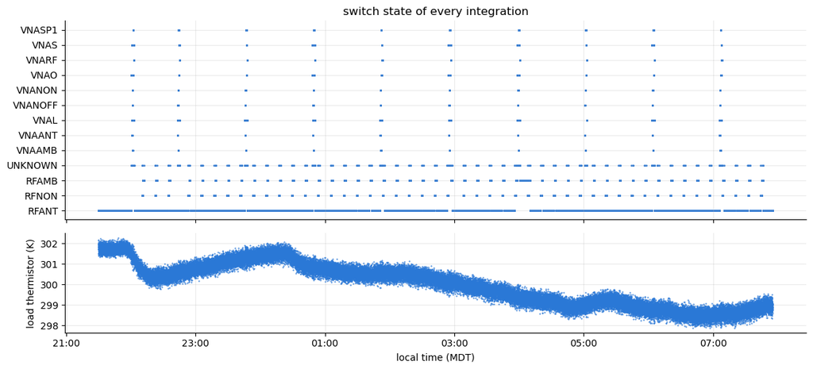

```python
d = yf.load_corr(CORR_DIR, START.timestamp(), STOP.timestamp(), KEY)
freqs = d['freqs']
zero = np.all(d['spec'] == 0, axis=1)
wrapped = d['spec'] < 0

fig, (ax0, ax1) = plt.subplots(2, 1, figsize=(12, 5.5), sharex=True, height_ratios=(2, 1))
states = [yf.SKY, yf.NOISE, yf.LOAD] + sorted(set(d['state']) - {yf.SKY, yf.NOISE, yf.LOAD})
ax0.scatter(as_num(d['time']), [states.index(s) for s in d['state']], s=1,
            color=C_STAGE[0], rasterized=True)
ax0.set_yticks(range(len(states)), states)
ax0.set_title('switch state of every integration')
ax1.plot(as_num(d['time']), d['t_load'], '.', ms=1, color=C_STAGE[0])
ax1.set_ylabel('load thermistor (K)')
time_axis(ax1.xaxis)
fig.tight_layout()
```

## 2. Visits, pairing, and the check against Christian's printed numbers

A visit is a contiguous run of one switch state, reduced to its **median** spectrum (int32 wraps in a few RFI channels would bias a mean). All-zero rows are the only exclusion. Each sky visit then takes the nearest load and noise-source visits in time, with no age limit.

Christian's notebook (run 2026-09-25 on his laptop, filtered D5 set) printed the values in the `christian` column; ours are computed here from the campaign archive.

```python
visits = yf.average_blocks(d, use=~zero)
sky, noise, load = (visits[s] for s in (yf.SKY, yf.NOISE, yf.LOAD))
i_load, age_load = yf.nearest(sky['t'], load['t'])
i_noise, age_noise = yf.nearest(sky['t'], noise['t'])
P_sky, P_load, P_noise = sky['spec'], load['spec'][i_load], noise['spec'][i_noise]
T_load = load['t_load'][i_load]

ours = {
    'integrations': len(d['time']),
    'files': len(set(d['file'])),
    'rows timed from filename': int(d['time_from_filename'].sum()),
    'all-zero rows': int(zero.sum()),
    'rows with a wrapped value': int(wrapped.any(axis=1).sum()),
    'channels with a wrapped value': int(wrapped.any(axis=0).sum()),
    'rows without thermistor': int(np.isnan(d['t_load']).sum()),
    'RFANT / RFNON / RFAMB rows': '/'.join(str((d['state'] == s).sum()) for s in (yf.SKY, yf.NOISE, yf.LOAD)),
    'RFANT / RFNON / RFAMB visits': '/'.join(str(len(visits[s]['t'])) for s in (yf.SKY, yf.NOISE, yf.LOAD)),
    'largest load age (min)': round(age_load.max() / 60, 1),
    'largest noise age (min)': round(age_noise.max() / 60, 1),
    'T_load min (K)': round(np.nanmin(T_load), 2),
    'T_load max (K)': round(np.nanmax(T_load), 2),
}
christian = {
    'integrations': 69849, 'files': 292, 'rows timed from filename': 0,
    'all-zero rows': 0, 'rows with a wrapped value': 289,
    'channels with a wrapped value': 16, 'rows without thermistor': 190,
    'RFANT / RFNON / RFAMB rows': '55459/5282/6096',
    'RFANT / RFNON / RFAMB visits': '54/48/49',
    'largest load age (min)': 26.5, 'largest noise age (min)': 25.6,
    'T_load min (K)': 298.46, 'T_load max (K)': 301.53,
}
check = pd.DataFrame({'ours': ours, 'christian': christian})
check['match'] = [str(a) == str(b) for a, b in zip(check.ours, check.christian)]
assert check.match.all(), check[~check.match]
check
```

|  | ours | christian | match |
| --- | --- | --- | --- |
| integrations | 69849 | 69849 | True |
| files | 292 | 292 | True |
| rows timed from filename | 0 | 0 | True |
| all-zero rows | 0 | 0 | True |
| rows with a wrapped value | 289 | 289 | True |
| channels with a wrapped value | 16 | 16 | True |
| rows without thermistor | 190 | 190 | True |
| RFANT / RFNON / RFAMB rows | 55459/5282/6096 | 55459/5282/6096 | True |
| RFANT / RFNON / RFAMB visits | 54/48/49 | 54/48/49 | True |
| largest load age (min) | 26.5 | 26.5 | True |
| largest noise age (min) | 25.6 | 25.6 | True |
| T_load min (K) | 298.46 | 298.46 | True |
| T_load max (K) | 301.53 | 301.53 | True |

## 3. Three-state Y factor

The uncalibrated antenna temperature at the receiver input. The bright dashes near 137 MHz are ORBCOMM passes during single sky visits.

```
log-log slope of the median T*: +0.83 (50-88 MHz), -2.46 (108-136 MHz)
```

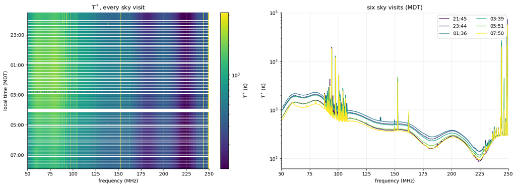

```python
T_star = yf.tant_star(P_sky, P_noise, P_load, T_load[:, None])

fig, (ax0, ax1) = plt.subplots(1, 2, figsize=(15, 5.5))
waterfall(ax0, sky, T_star, freqs, r'$T^*$ (K)')
ax0.set_title(r'$T^*$, every sky visit')
cmap = plt.get_cmap('viridis')
pick = np.linspace(0, len(sky['t']) - 1, 6).astype(int)
for j, i in enumerate(pick):
    t = datetime.fromtimestamp(sky['t'][i], TZ)
    ax1.semilogy(freqs, np.where(T_star[i] > 0, T_star[i], np.nan),
                 color=cmap(j / (len(pick) - 1)), label=f'{t:%H:%M}')
ax1.set(xlim=PLOT_FREQ_MHZ, xlabel='frequency (MHz)', ylabel=r'$T^*$ (K)',
        title='six sky visits (MDT)')
ax1.legend(ncol=2)
fig.tight_layout()

def loglog_slope(T, lo, hi):
    k = band(freqs, (lo, hi))
    return np.polyfit(np.log(freqs[k]), np.log(np.median(T[:, k], axis=0)), 1)[0]

print('log-log slope of the median T*: '
      f'{loglog_slope(T_star, 50, 88):+.2f} (50-88 MHz), '
      f'{loglog_slope(T_star, 108, 136):+.2f} (108-136 MHz)')
```

Christian's README quotes T* slopes of +0.82 (50–88 MHz) and −2.45 (108–136 MHz) for this night, computed outside his notebook with an unstated fit. A straight log-log fit to the median spectrum gives the values above (+0.83, −2.46); a fit to the mean spectrum gives +0.82 and −2.38. That is close, not an exact check; the exact checks are § 2 and § 6.

## 4. S11 at plane P with `eigsep_cal.S11`

`S11(S11_DIR).calibrate(switchpaths, osldata)` runs, per sweep:

1. the VNA error network, solved from the sweep's internal O/S/L traces against their characterization, and removed (`vna` plane);
2. the VNA-leg switch path de-embedded (`dut` plane);
3. the RF-leg switch path embedded (`lna` plane = P). The receiver has no RF leg and stops at `dut`.

A sweep whose own internal OSL is zero-filled (cmt_vna #54) borrows the nearest valid one of the same mode, as Christian's chain does; zero-filled DUT traces are skipped. `default` is the deepest plane each DUT reaches. The antenna $\Gamma$ includes the balun and feed coax.

```
skipped files: none
{'ant': 18, 'amb': 18, 'rec': 20} calibrated sweeps (all 40 files)
```

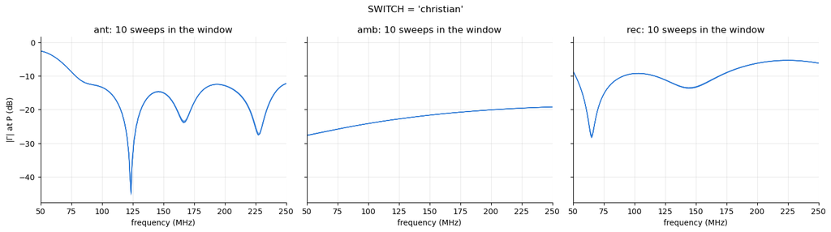

```python
def s11_at_p(switch):
    s = S11(S11_DIR).calibrate(SWITCH_FILES[switch], INTERNAL_OSL)
    out = {}
    for dut in ('ant', 'amb', 'rec'):
        t, g = s.get_all_s11s(dut, 'default')
        out[dut] = {'t': np.asarray(t, float), 'gamma': np.asarray(g)}
    return s.freqs, out, s

freqs_s11, s11, s11_obj = s11_at_p(SWITCH)
print('skipped files:', s11_obj.skipped or 'none')
print({dut: len(v['t']) for dut, v in s11.items()}, 'calibrated sweeps (all 40 files)')

fig, axes = plt.subplots(1, 3, figsize=(15, 4.2), sharey=True)
win = lambda t: (t >= START.timestamp()) & (t < STOP.timestamp())
for ax, dut in zip(axes, ('ant', 'amb', 'rec')):
    keep = win(s11[dut]['t'])
    for g in s11[dut]['gamma'][keep]:
        ax.plot(freqs_s11 / 1e6, 20 * np.log10(np.abs(g)), lw=0.8, color=C_STAGE[0], alpha=0.6)
    ax.set(xlim=PLOT_FREQ_MHZ, xlabel='frequency (MHz)',
           title=f'{dut}: {keep.sum()} sweeps in the window')
axes[0].set_ylabel(r'$|\Gamma|$ at P (dB)')
fig.suptitle(f'SWITCH = {SWITCH!r}')
fig.tight_layout()
```

## 5. The two S11 corrections

Each sky visit takes the antenna, ambient-load and receiver sweeps nearest in time (largest ages printed). The 1000-point S11 grid goes onto the correlator channels by linear interpolation of real and imaginary parts. The receiver-S11 correction assumes equal gain on every switch path, no receiver noise waves, and $T_\mathrm{NS}$ as the excess delivered to the receiver.

```
largest S11 age (min): {'ant': np.float64(31.6), 'amb': np.float64(31.6), 'rec': np.float64(30.8)} | Christian: ant 31.6, amb 31.6, rec 30.8
```

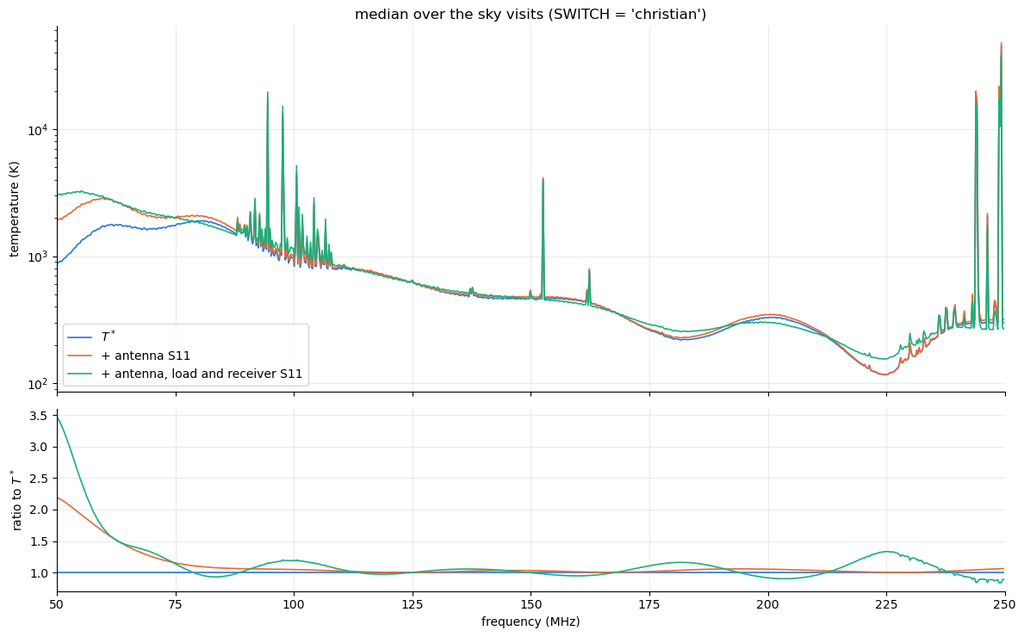

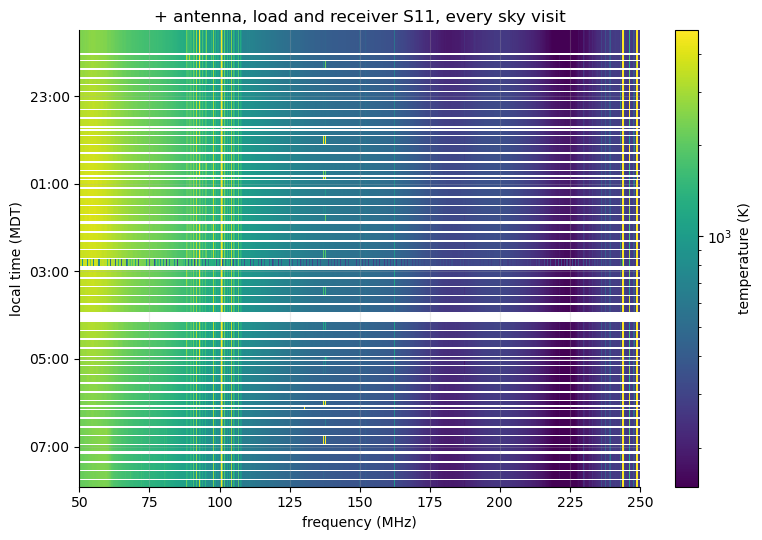

```python
def corrections(s11):
    gam, age = {}, {}
    for dut in ('ant', 'amb', 'rec'):
        i, age[dut] = yf.nearest(sky['t'], s11[dut]['t'])
        gam[dut] = yf.s11_to_channels(s11[dut]['gamma'][i], freqs_s11 / 1e6, freqs)
    T_ant = yf.correct_antenna_s11(T_star, gam['ant'])
    T_rec = yf.correct_receiver_s11(T_star, T_load[:, None], gam['ant'], gam['amb'], gam['rec'])
    return gam, age, T_ant, T_rec

gam, age_s11, T_ant_s11, T_rec_s11 = corrections(s11)
print('largest S11 age (min):', {k: round(v.max() / 60, 1) for k, v in age_s11.items()},
      '| Christian: ant 31.6, amb 31.6, rec 30.8')

f = band(freqs, PLOT_FREQ_MHZ)
fig, (ax0, ax1) = plt.subplots(2, 1, figsize=(12, 7.5), sharex=True, height_ratios=(2, 1))
for arr, label, c in zip((T_star, T_ant_s11, T_rec_s11),
                         (r'$T^*$', '+ antenna S11', '+ antenna, load and receiver S11'), C_STAGE):
    med = np.median(arr[:, f], axis=0)
    ax0.semilogy(freqs[f], np.where(med > 0, med, np.nan), color=c, label=label)
    ax1.plot(freqs[f], np.median(arr[:, f] / T_star[:, f], axis=0), color=c)
ax0.set(ylabel='temperature (K)', title=f'median over the sky visits (SWITCH = {SWITCH!r})')
ax0.legend()
ax1.set(xlim=PLOT_FREQ_MHZ, xlabel='frequency (MHz)', ylabel=r'ratio to $T^*$')
fig.tight_layout()

fig, ax = plt.subplots(figsize=(8, 5.5))
waterfall(ax, sky, T_rec_s11, freqs, 'temperature (K)')
ax.set_title('+ antenna, load and receiver S11, every sky visit')
fig.tight_layout()
```

## 6. Cross-checks

```python
_, osl_from_raw = yf.characterize_internal_osl(INTERNAL_OSL_RAW)
o = np.load(INTERNAL_OSL)
print('internal-OSL characterization, eigsep_cal packaged vs from Christian raw capture: '
      f'max|d| = {np.abs(np.array([o["O"], o["S"], o["L"]]) - osl_from_raw).max():.1e}')

_, s11_ref, log = yf.calibrate_s11(S11_DIR, INTERNAL_OSL_RAW, SWITCH_FILES['christian'])
_, s11_chr, _ = s11_at_p('christian')
rows = []
for dut in ('ant', 'amb', 'rec'):
    same_t = np.array_equal(s11_ref[dut]['t'], s11_chr[dut]['t'])
    rows.append({'dut': dut, 'sweeps (Christian)': len(s11_ref[dut]['t']),
                 'sweeps (eigsep_cal)': len(s11_chr[dut]['t']), 'same times': same_t,
                 'max |dGamma|': np.abs(s11_ref[dut]['gamma'] - s11_chr[dut]['gamma']).max()
                 if same_t else np.nan})
xa = pd.DataFrame(rows).set_index('dut')
assert (xa['max |dGamma|'] < 1e-12).all()
xa.style.format({'max |dGamma|': '{:.1e}'})
```

```
internal-OSL characterization, eigsep_cal packaged vs from Christian raw capture: max|d| = 9.0e-16
```

| dut | sweeps (Christian) | sweeps (eigsep_cal) | same times | max \|dGamma\| |
| --- | --- | --- | --- | --- |
| ant | 18 | 18 | True | 1.4e-15 |
| amb | 18 | 18 | True | 8.9e-16 |
| rec | 20 | 20 | True | 1.4e-15 |

**(b) What the switch file does.** Both characterizations run through the same chain and the same corrections; only `SWITCH_FILES` differs.

|  | max \|dGamma\| at P | mean \|Gamma\| 50-200 MHz, christian | mean \|Gamma\| 50-200 MHz, eigsep_cal |
| --- | --- | --- | --- |
| ant | 0.012 | 0.233 | 0.234 |
| amb | 0.013 | 0.072 | 0.075 |
| rec | 0.260 | 0.305 | 0.330 |

```
T (ant+load+rec S11), eigsep_cal / christian,  50- 88 MHz: median over visits spans 0.951 .. 1.062
T (ant+load+rec S11), eigsep_cal / christian,  88-108 MHz: median over visits spans 0.966 .. 1.029
T (ant+load+rec S11), eigsep_cal / christian, 108-136 MHz: median over visits spans 0.993 .. 1.027
T (ant+load+rec S11), eigsep_cal / christian, 136-200 MHz: median over visits spans 0.984 .. 1.023
T (ant+load+rec S11), eigsep_cal / christian, 200-250 MHz: median over visits spans 0.944 .. 1.029
```

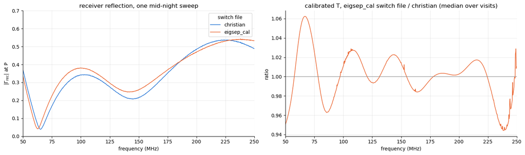

```python
res = {}
for sw in SWITCH_FILES:
    _, s, _ = s11_at_p(sw)
    res[sw] = (s, *corrections(s))

s_c, s_e = res['christian'][0], res['eigsep_cal'][0]
fs = freqs_s11 / 1e6
bs = (fs >= 50) & (fs < 200)
tab = pd.DataFrame({dut: {
    'max |dGamma| at P': np.abs(s_c[dut]['gamma'] - s_e[dut]['gamma']).max(),
    'mean |Gamma| 50-200 MHz, christian': np.abs(s_c[dut]['gamma'][:, bs]).mean(),
    'mean |Gamma| 50-200 MHz, eigsep_cal': np.abs(s_e[dut]['gamma'][:, bs]).mean(),
} for dut in ('ant', 'amb', 'rec')}).T
display(tab.round(3))

with np.errstate(invalid='ignore', divide='ignore'):     # NaN below 1 MHz
    ratio = res['eigsep_cal'][4] / res['christian'][4]  # T_rec_s11
for lo, hi in [(50, 88), (88, 108), (108, 136), (136, 200), (200, 250)]:
    k = band(freqs, (lo, hi))
    r = np.median(ratio[:, k], axis=0)
    print(f'T (ant+load+rec S11), eigsep_cal / christian, {lo:3d}-{hi:3d} MHz: '
          f'median over visits spans {r.min():.3f} .. {r.max():.3f}')

fig, (ax0, ax1) = plt.subplots(1, 2, figsize=(15, 4.5))
i_mid = np.argmin(np.abs(s_c['rec']['t'] - 0.5 * (START.timestamp() + STOP.timestamp())))
for sw, c in C_SWITCH.items():
    ax0.plot(fs, np.abs(res[sw][0]['rec']['gamma'][i_mid]), color=c, label=sw)
ax0.set(xlim=PLOT_FREQ_MHZ, ylim=(0, 0.7), xlabel='frequency (MHz)', ylabel=r'$|\Gamma_\mathrm{rec}|$ at P',
        title='receiver reflection, one mid-night sweep')
ax0.legend(title='switch file')
ax1.plot(freqs[f], np.median(ratio[:, f], axis=0), color=C_SWITCH['eigsep_cal'])
ax1.axhline(1, color='0.5', lw=0.8)
ax1.set(xlim=PLOT_FREQ_MHZ, xlabel='frequency (MHz)', ylabel='ratio',
        title='calibrated T, eigsep_cal switch file / christian (median over visits)')
fig.tight_layout()
```

## 7. What you have

On native correlator channels `freqs` (MHz), one row per sky visit (`sky['t']`, `sky['t_start']`, `sky['t_stop']` in unix s):

| Array | Contents |
| --- | --- |
| `P_sky`, `P_load`, `P_noise` | visit spectra (counts): sky and its nearest load / noise-source visits |
| `T_load` | thermistor temperature of the nearest load visit (K) |
| `T_star` | three-state Y factor (K) |
| `gam['ant']`, `gam['amb']`, `gam['rec']` | nearest-in-time $\Gamma$ at P, from `SWITCH` |
| `T_ant_s11`, `T_rec_s11` | `T_star` with the antenna, and antenna + load + receiver, S11 corrections |
| `res[switch]` | `(s11, gam, age, T_ant_s11, T_rec_s11)` for each switch file |
| `age_load`, `age_noise`, `age_s11` | time from each sky visit to what it was paired with (s) |

**Not settled here:** which switch characterization is current; $T_\mathrm{NS}$ (nameplate, and the injection drifts through the night); any noise-wave or loss term.